# Your Digest for Saturday, Mar 23, 2024 11:59 PM

## ⭐Membranoproliferative glomerulonephritis

- ⭐It is *uncommon*.
- **mixed nephrotic / nephritic picture**. => nephrotic Xn + haematuria, hypertension and impaired renal function
- ?commonly presents as nephrotic syndrome <- confirm.
- **recurs in renal transplant** patients.
- There is proliferation of mesangial cells, endothelial cells and the mesangial matrix.
- There is **IgG deposition.**
- Type 1: **subendothelial** immune complex deposition (or interposition of mesangial cells in the subendothelial space) -> splitting of capillary basement membrane -> *tramline appearance*. (Mnemonic: "All aboard the proliferative train") -> Tramlines

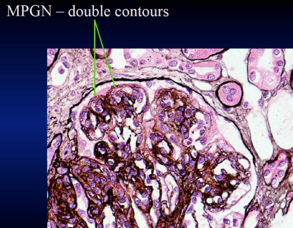

**Histology**:

- Hypercellularity **AND** thickening of the glomerular basement membrane.

1. Autoimmune
   1. SLE, Sjogren's, Rheumatoid Arthritis
   2. Systemic sclerosis
   3. Scleroderma
   4. Inherited complement deficiency: C2 deficiency
2. Chronic infections
   1. Hep B, Hep C, Bacterial endocarditis, Schistosoma, Malaria  
      [Source](https://emedicine.medscape.com/article/240056-overview#a5)

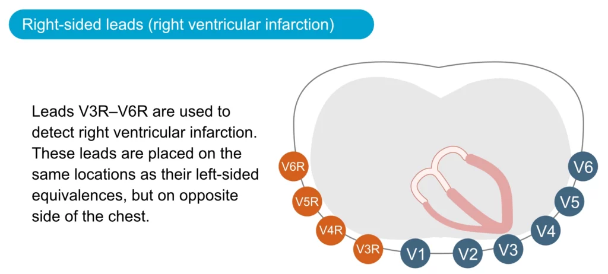

#2015MCQ-APR/15

| Group 1 | Group 2 |
| --- | --- |
| Eliminated by hepatic metabolism | Eliminated unchanged by kidney |
| **Lipid soluble** | **water soluble** |
| High CNS penetration (more SE) | poor CNS penetration |
| short half lives | longer half lives |
| variable bioavailability | less variable |
| **propranolol** and **metoprolol** | Atenolol, sotalol |

[figure not shown]

> **Left anterolateral papillary muscles** derives from branches of the left coronary artery. The blood supply to the **left posteromedial papillary muscles** most commonly derives from the **right coronary artery** [Source](https://www.ncbi.nlm.nih.gov/books/NBK557802/)

```
- Sulfonamides are synthetic bacteriostatic antibiotics that competitively inhibit conversion of p-aminobenzoic acid to dihydropteroate, which bacteria need for folate synthesis and ultimately purine and DNA synthesis. Humans do not synthesize folate but acquire it in their diet, so their DNA synthesis is less affected.[Source](https://www.msdmanuals.com/professional/infectious-diseases/bacteria-and-antibacterial-drugs/sulfonamides)
```

# CNS penetration of antibiotics

| **Excellent/Good penetration of the CSF** | **Good penetration only in inflamed meninges** | **Poor penetration of the CSF** |
| --- | --- | --- |
| Fluoroquinolones | Glycopeptides (vancomycin) | *Beta-lactams* 3 |
| TMP/SMX | Macrolides (azithromycin) | *Aminoglycosides* |
| Metronidazole | Rifampin | Tetracyclines (doxy, tigecycline) |
| Chloramphenicol | Ethambutol | Clindamycin 4 |
| Fosfomycin1 |  | Daptomycin |
| Isoniazid |  | Colistin |
| Pyrazinamide |  | Fusion inhibitors (enfurvitide) |
| Zidovudine |  | Tenofovir |
| 5-flucytosine |  | *Amphotericin* B5 |
| Voriconazole/fluconazole |  | Echinocandins |
| Pyrimethamine |  | Itraconazole/posaconazole |
| Atovaquone?2 |  |  |
| Albendazole >>> Praziquantel |  |  |
| [Source](https://foamid.com/2018/03/11/cns-penetration-of-antimicrobials/) |  |  |

> 1 only FDA-approved for UTI treatment  
> 2 no studies have been published looking at CNS penetration; however has been used successfully in clinical CNS infections  
> 3 overcome by increase in dosages – higher dosages of beta-lactams obtain adequate levels in the CSF and tend to be 1st line agents in bacterial meningitis due to their efficacy and bactericidal properties  
> 4 however has been shown to effectively treat susceptible CNS infections  
> 5 however clinical trials have shown good outcomes when used in treatment of CNS infections

# Antibiotgram

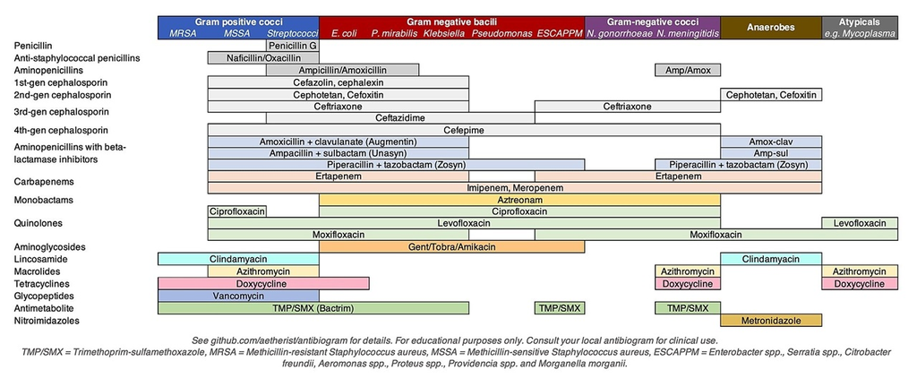

**Netilmicin** has a similar spectrum to that of gentamicin. Some sources say it has less activity against pseudomonas. However, it still **works against pseudomonas**.  
[Source](https://drugs.ncats.io/drug/4O5J85GJJB)

# Antivirals

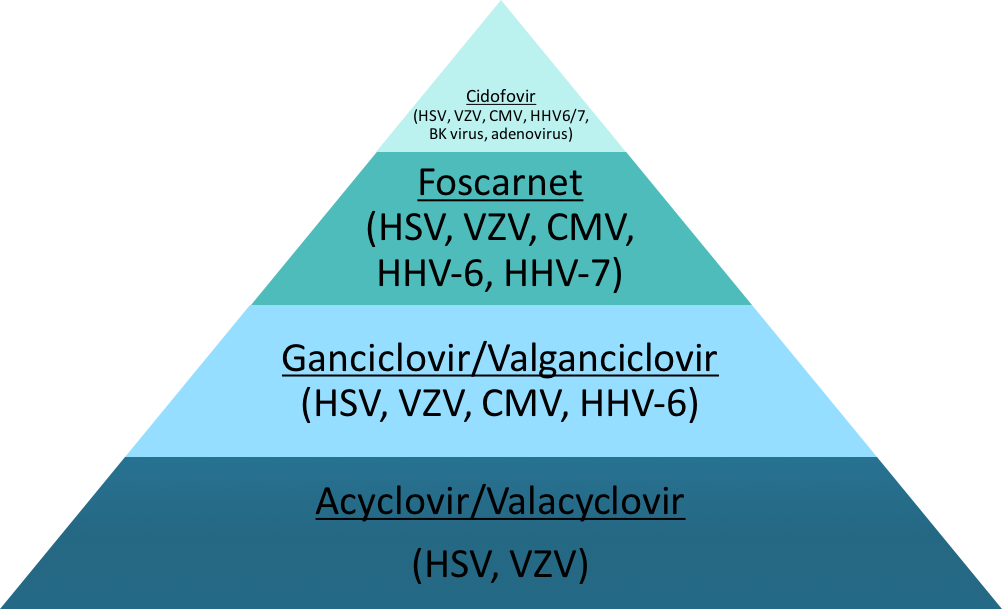

[Source](https://foamid.com/2018/03/26/antimicrobials-spectrum-of-activity/)  
Foscarnet and cidofovir are toxic.

Patient inhales CO and a tracer gas (helium) in a single breath. Breath is held for 10 seconds. Then a gas sample is collected from raidly exhaled breath.

# Uric acid nephropathy

Uric acid is insoluble. Urate is slightly more soluble. Therefore, precipitation is increased in acidic environments. Humans do not have the uricase enzyme which converts urate to soluble allantoin.  
There are 3 forms of uric acid induced nephropathy:

[Source](https://emedicine.medscape.com/article/244255-overview#a7)

1. Acute uric acid nephropathy
   1. Occurs in background of leukaemia and lymphoma. Massive increased purine metabolism causes uric acid to precipitate in the distal nephron causing obstruction and compression of nearby vessels leading to oliguric AKI.
2. Chronic urate nephropathy
   1. Some controversy about the existence of this entry.
   2. Pathophysiology is the formation of micro tophi of monosodium urate which then sets up chronic inflammation and granulomas.
3. Urate stones